# WYu HW5

Wuyue Yu

11/8/2019

## Tree-Based Methods

```r
data("Carseats")
carseats = Carseats
summary(carseats)
```

```
##      Sales          CompPrice       Income        Advertising
##  Min.   : 0.000   Min.   : 77   Min.   : 21.00   Min.   : 0.000
##  1st Qu.: 5.390   1st Qu.:115   1st Qu.: 42.75   1st Qu.: 0.000
##  Median : 7.490   Median :125   Median : 69.00   Median : 5.000
##  Mean   : 7.496   Mean   :125   Mean   : 68.66   Mean   : 6.635
##  3rd Qu.: 9.320   3rd Qu.:135   3rd Qu.: 91.00   3rd Qu.:12.000
##  Max.   :16.270   Max.   :175   Max.   :120.00   Max.   :29.000
##    Population        Price        ShelveLoc        Age
##  Min.   : 10.0   Min.   : 24.0   Bad   : 96   Min.   :25.00
##  1st Qu.:139.0   1st Qu.:100.0   Good  : 85   1st Qu.:39.75
##  Median :272.0   Median :117.0   Medium:219   Median :54.50
##  Mean   :264.8   Mean   :115.8                Mean   :53.32
##  3rd Qu.:398.5   3rd Qu.:131.0                3rd Qu.:66.00
##  Max.   :509.0   Max.   :191.0                Max.   :80.00
##    Education    Urban       US
##  Min.   :10.0   No :118   No :142
##  1st Qu.:12.0   Yes:282   Yes:258
##  Median :14.0
##  Mean   :13.9
##  3rd Qu.:16.0
##  Max.   :18.0
```

```r
head(carseats)
```

```
##   Sales CompPrice Income Advertising Population Price ShelveLoc Age
## 1  9.50       138     73          11        276   120       Bad  42
## 2 11.22       111     48          16        260    83      Good  65
## 3 10.06       113     35          10        269    80    Medium  59
## 4  7.40       117    100           4        466    97    Medium  55
## 5  4.15       141     64           3        340   128       Bad  38
## 6 10.81       124    113          13        501    72       Bad  78
##   Education Urban  US
## 1        17   Yes Yes
## 2        10   Yes Yes
## 3        12   Yes Yes
## 4        14   Yes Yes
## 5        13   Yes  No
## 6        16    No Yes
```

1. Attempt a regression tree-based method (not covered in this tutorial) on a reasonable dataset of your choice. Explain the results.

```r
#Set seed to make results reproducible
set.seed(29)

#Split data into train and test subset (250 and 150 respectively)
train = sample(1:nrow(carseats), 250)

#Fit train subset of data to model
tree.carseats = rpart(Sales ~ ., carseats, subset=train, method = "anova")
printcp(tree.carseats)
```

```
##
## Regression tree:
## rpart(formula = Sales ~ ., data = carseats, subset = train, method = "anova")
##
## Variables actually used in tree construction:
## [1] Advertising Age         CompPrice   Income      Population  Price
## [7] ShelveLoc   US
##
## Root node error: 1931.6/250 = 7.7263
##
## n= 250
##
##          CP nsplit rel error  xerror     xstd
## 1  0.227549      0   1.00000 1.01107 0.091530
## 2  0.076029      1   0.77245 0.79266 0.069538
## 3  0.072696      2   0.69642 0.83048 0.071103
## 4  0.060030      3   0.62373 0.85991 0.071400
## 5  0.035445      4   0.56370 0.76300 0.058818
## 6  0.024047      6   0.49281 0.72599 0.057420
## 7  0.022519      7   0.46876 0.72836 0.055123
## 8  0.019911      8   0.44624 0.73627 0.055726
## 9  0.019132      9   0.42633 0.75490 0.057343
## 10 0.013824     10   0.40720 0.72187 0.054158
## 11 0.012468     11   0.39337 0.70290 0.052080
## 12 0.012375     12   0.38090 0.69767 0.051953
## 13 0.012210     14   0.35616 0.69767 0.051953
## 14 0.012161     15   0.34395 0.69767 0.051953
## 15 0.011184     16   0.33178 0.70072 0.052078
## 16 0.010000     17   0.32060 0.71010 0.052279
```

```r
summary(tree.carseats)
```

```
## Call:
## rpart(formula = Sales ~ ., data = carseats, subset = train, method = "anova")
##   n= 250
##
##            CP nsplit rel error    xerror       xstd
## 1  0.22754869      0 1.0000000 1.0110724 0.09152986
## 2  0.07602943      1 0.7724513 0.7926645 0.06953820
## 3  0.07269557      2 0.6964219 0.8304754 0.07110319
## 4  0.06002957      3 0.6237263 0.8599086 0.07140046
## 5  0.03544534      4 0.5636967 0.7630037 0.05881807
## 6  0.02404696      6 0.4928061 0.7259865 0.05741990
## 7  0.02251853      7 0.4687591 0.7283642 0.05512282
## 8  0.01991141      8 0.4462406 0.7362726 0.05572588
## 9  0.01913211      9 0.4263292 0.7548999 0.05734303
## 10 0.01382439     10 0.4071970 0.7218679 0.05415752
## 11 0.01246769     11 0.3933727 0.7029048 0.05207956
## 12 0.01237495     12 0.3809050 0.6976672 0.05195336
## 13 0.01220954     14 0.3561551 0.6976672 0.05195336
## 14 0.01216083     15 0.3439455 0.6976672 0.05195336
## 15 0.01118375     16 0.3317847 0.7007233 0.05207772
## 16 0.01000000     17 0.3206010 0.7100993 0.05227862
##
## Variable importance
##   ShelveLoc       Price   CompPrice         Age Advertising      Income
##          31          24          11           9           8           5
##   Education          US  Population
##           5           4           3
##
## Node number 1: 250 observations,    complexity param=0.2275487
##   mean=7.44612, MSE=7.726299
##   left son=2 (199 obs) right son=3 (51 obs)
##   Primary splits:
##       ShelveLoc   splits as  LRL,       improve=0.22754870, (0 missing)
##       Price       < 94.5  to the right, improve=0.13240420, (0 missing)
##       Age         < 60.5  to the right, improve=0.09283130, (0 missing)
##       Advertising < 7.5   to the left,  improve=0.04619337, (0 missing)
##       Income      < 36.5  to the left,  improve=0.03002408, (0 missing)
##
## Node number 2: 199 observations,    complexity param=0.07602943
##   mean=6.774874, MSE=5.760062
```

[output cut: 265 more lines]

```
##       Advertising < 1.5   to the right, agree=0.714, adj=0.250, (0 split)
##       Price       < 93.5  to the right, agree=0.714, adj=0.250, (0 split)
##       Urban       splits as  RL,        agree=0.667, adj=0.125, (0 split)
##
## Node number 78: 24 observations
##   mean=7.422917, MSE=2.169121
##
## Node number 79: 22 observations
##   mean=9.434545, MSE=1.662643
##
## Node number 154: 13 observations
##   mean=6.222308, MSE=1.194972
##
## Node number 155: 8 observations
##   mean=8.48125, MSE=1.134611
```

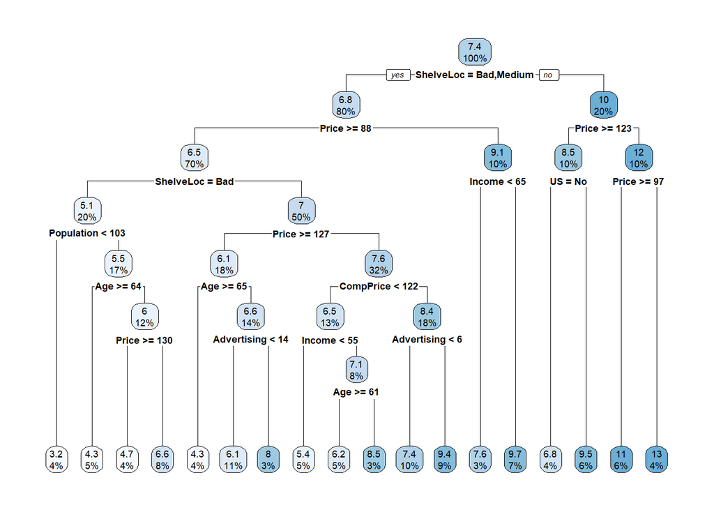

```r
#Visualize tree
rpart.plot(tree.carseats)
```

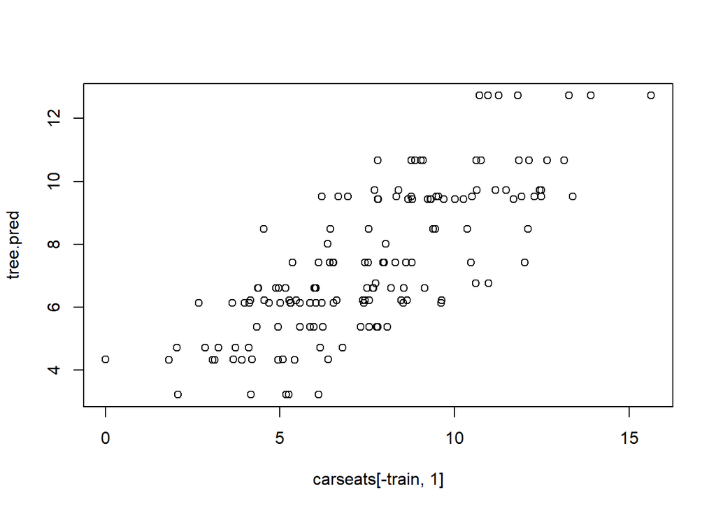

```r
#Use model on test set, predict sales
tree.pred = predict(tree.carseats, carseats[-train,])
plot(carseats[-train,1],tree.pred)
```

```r
rmse(carseats[-train,1],tree.pred)
```

```
## [1] 1.84955
```

Carseats dataset chosen to predict sales with other variables.  
Regression tree as plotted.  
Variables used in model: Advertising, Age, CompPrice, Income, Population, Price, ShelveLoc, US  
17 internal nodes, 18 terminal nodes.  
Sales predicted for test set. RMSE is 1.84955; on average, predicted sales are about 1.85 thousand units off from the actual sales.

2. Attempt both a bagging and boosting method on a reasonable dataset of your choice. Explain the results.  
   ##Bagging

```r
set.seed(1)

oob.err = double(10)
test.err = double(10)

#find mtry and ntree
for(mtry in 1:10){
  fit = randomForest(Sales ~ ., carseats, subset=train, mtry = mtry, ntree = 500)
  oob.err[mtry] = fit$mse[500] ##extract Mean-squared-error
  pred = predict(fit, carseats[-train,]) #predict on test dataset
  test.err[mtry] = with(carseats[-train,], mean( (Sales-pred)^2 )) #compute test error
}

bagging.carseats = randomForest(Sales~., data = carseats, subset = train, mtry = 10, ntree = 500)
bagging.carseats
```

```
##
## Call:
##  randomForest(formula = Sales ~ ., data = carseats, mtry = 10,      ntree = 500, subset = train)
##                Type of random forest: regression
##                      Number of trees: 500
## No. of variables tried at each split: 10
##
##           Mean of squared residuals: 2.681223
##                     % Var explained: 65.3
```

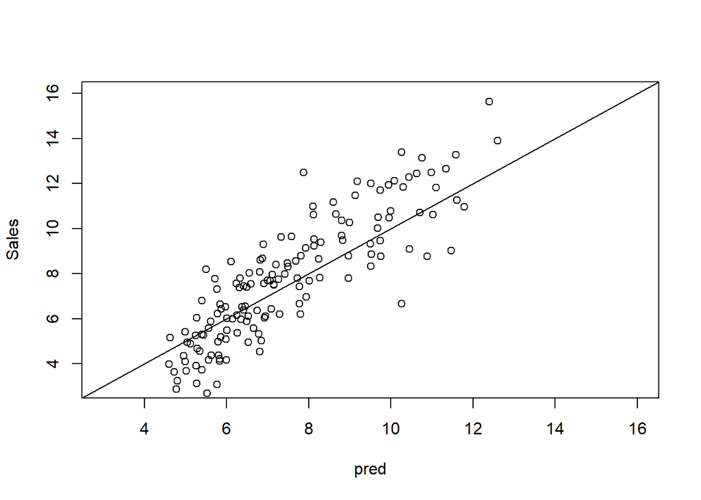

```r
#Visualize
plot(pred,carseats[-train,1], ylab = "Sales", xlim = c(3,16), ylim = c(3,16))
abline(0,1)
```

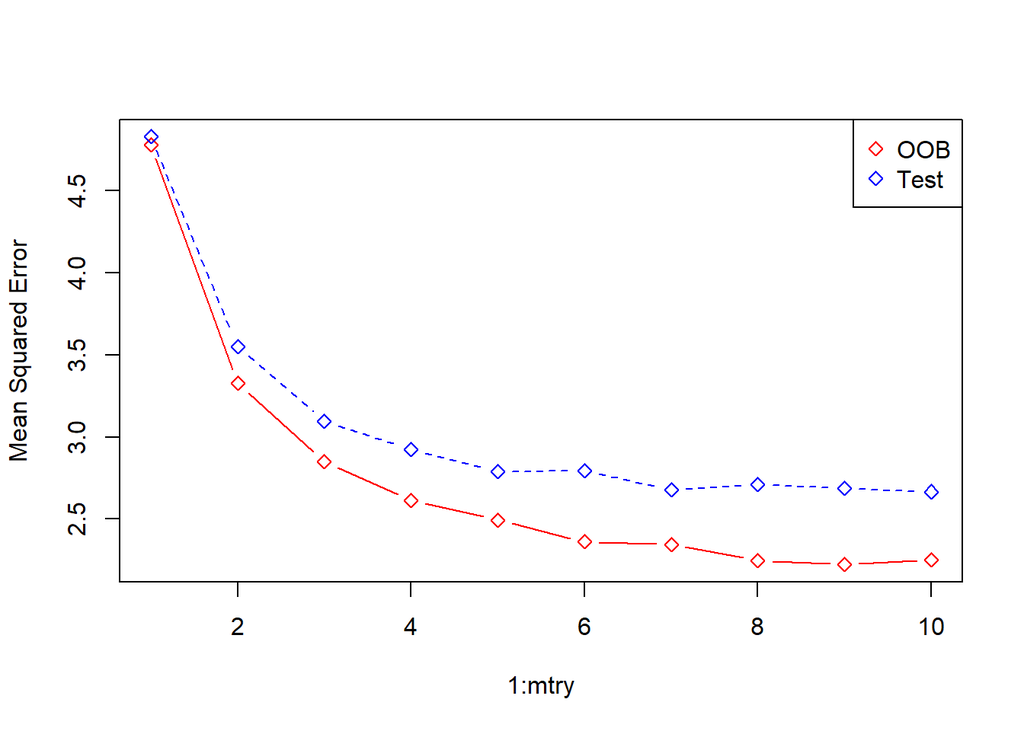

```r
matplot(1:mtry, cbind(test.err, oob.err), pch = 23, col = c("red", "blue"), type = "b", ylab="Mean Squared Error")
legend("topright", legend = c("OOB", "Test"), pch = 23, col = c("red", "blue"))
```

Random forest uses a random sample of m predicting features each time to fit a tree. Number of predictors and trees are tuned.  
Training and test errors both decrease as number of predictors increases.  
Multiple ntree values attempted. Increasing ntree grows a larger number of trees in random forest, stablizing the model, resulting in a lower mean of squared residuals and a higher percentage of var explained.  
mtry = 10, ntree = 500 selected for model.

##Boosting

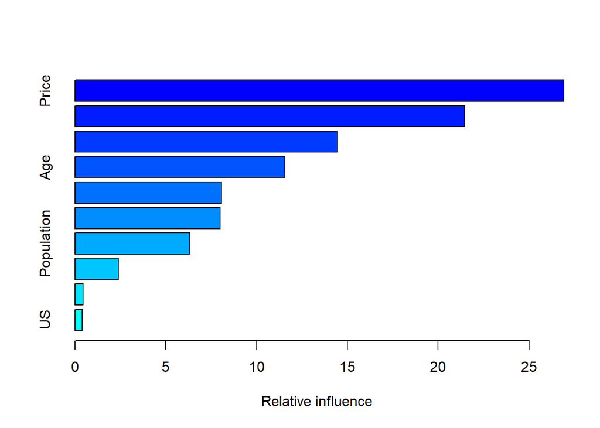

```
##                     var    rel.inf
## Price             Price 26.9206257
## ShelveLoc     ShelveLoc 21.4571298
## CompPrice     CompPrice 14.4598932
## Age                 Age 11.5633428
## Income           Income  8.0646957
## Advertising Advertising  8.0015369
## Population   Population  6.3146057
## Education     Education  2.3944641
## Urban             Urban  0.4368181
## US                   US  0.3868882
```

```r
set.seed(1)
#Gradient Boosting Model
boost.carseats = gbm(Sales~., data = carseats[train,], distribution = "gaussian", n.trees = 10000, shrinkage = 0.01, interaction.depth = 4)

#Variable Importance Plot
summary(boost.carseats)
```

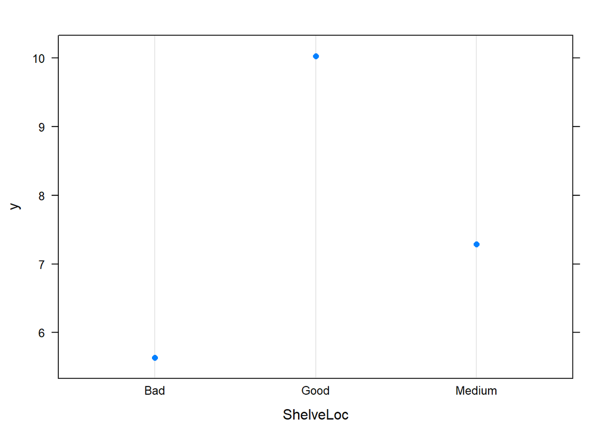

```r
#Visualize important variables of interest
plot(boost.carseats,i="ShelveLoc")
```

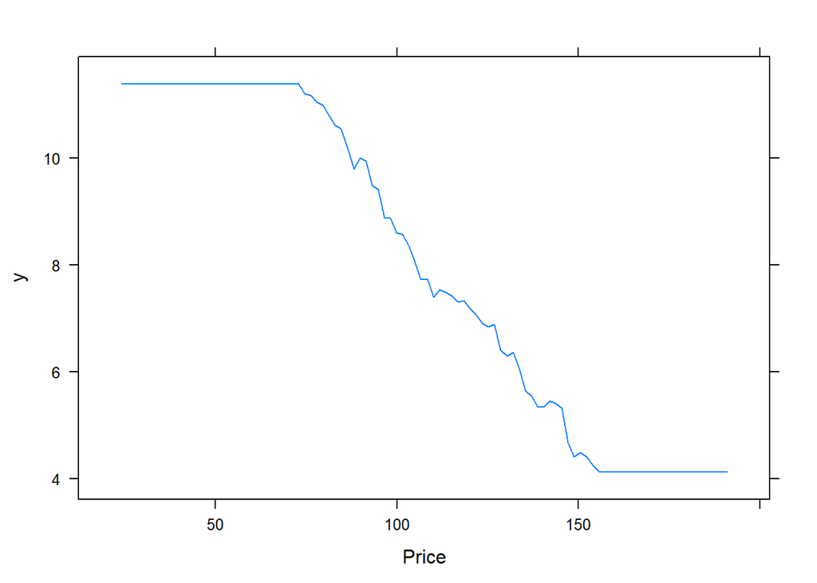

```r
plot(boost.carseats,i="Price")
```

```r
#Predict on test set
n.trees = seq(from = 100, to = 10000, by = 100)
predmat = predict(boost.carseats, newdata = carseats[-train,], n.trees = n.trees)
dim(predmat)
```

```
## [1] 150 100
```

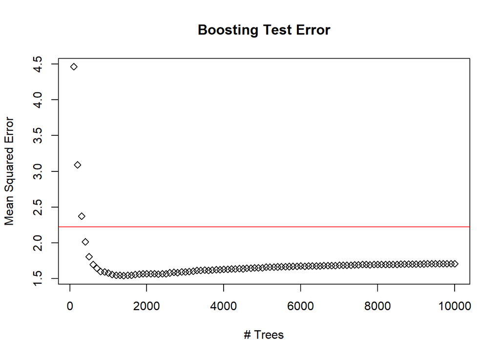

```r
#Visualize Boosting Error Plot
boost.err = with(carseats[-train,], apply( (predmat - Sales)^2, 2, mean) )
plot(n.trees, boost.err, pch = 23, ylab = "Mean Squared Error", xlab = "# Trees", main = "Boosting Test Error")
abline(h = min(test.err), col = "red")
```

Boosting uses information from previously grown trees to sequentially train following tree models.  
Relative influences of variables are shown, with importance of Price and ShelveLoc visualized.  
Mean squared error decreases with increasing number of trees, reaches minimum at ~1200 trees, slightly increases again and plateaus out. Therefore n.trees should be set to ~1200.